# Unsupervised learning tools

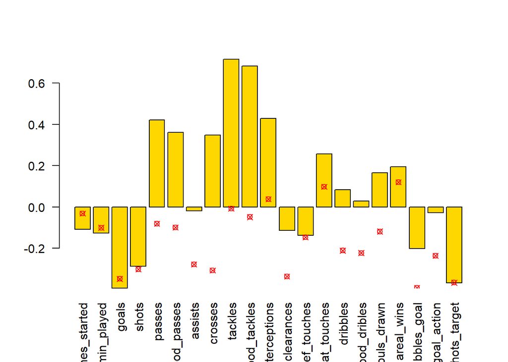

```r
# Center 3 :
bar1=barplot(centers4[3,], las=2, col="gold")
points(bar1,y=apply(X, 2, quantile, 0.50),col="red",pch=13)
```

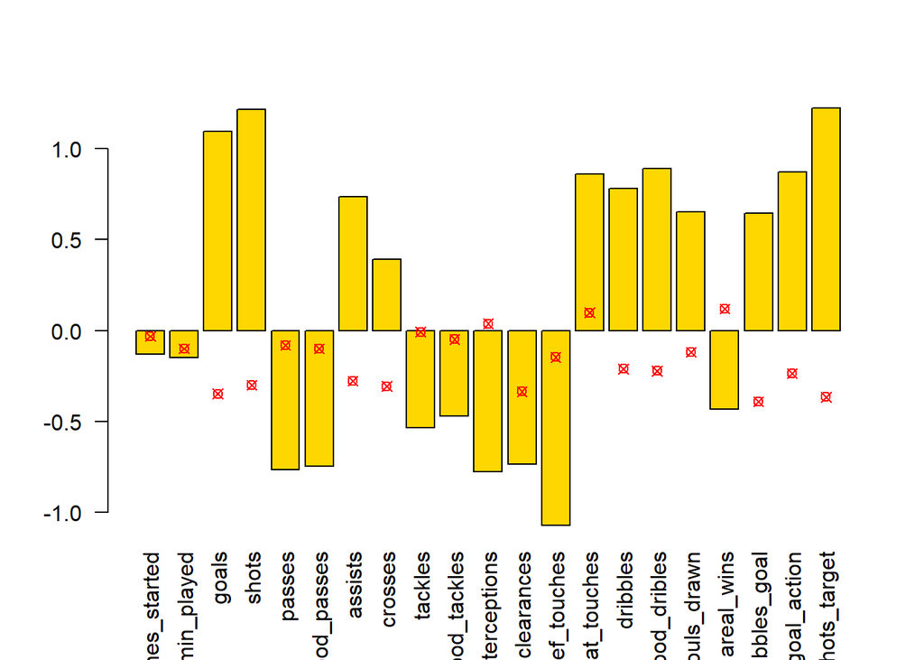

```r
# Center 4 :
bar1=barplot(centers4[4,], las=2, col="gold")
points(bar1,y=apply(X, 2, quantile, 0.50),col="red",pch=13)
```

With the following plot we see our assumptions are confirmed, the cluster indeed indicates position, we can look at some players in the plot to see that.

This doesn’t mean that there can’t be some mistakes in the classification but overall, it seems very good.

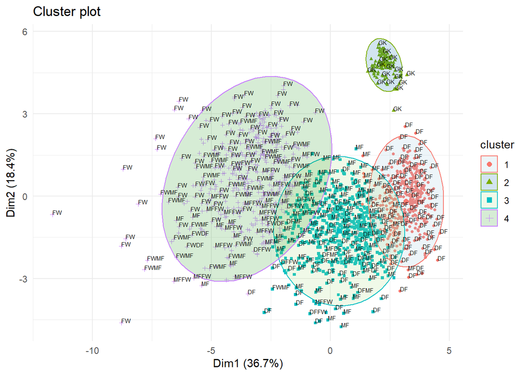

```r
fviz_cluster(fit.4, data = X, geom = c("point"),ellipse.type = 'norm', pointsize=1)+theme_minimal()+geom_text(label=players$position,hjust=0, vjust=0,size=2,check_overlap = T)+scale_fill_brewer(palette="Paired")
```

We can take a look at the silhouette with 4 clusters.

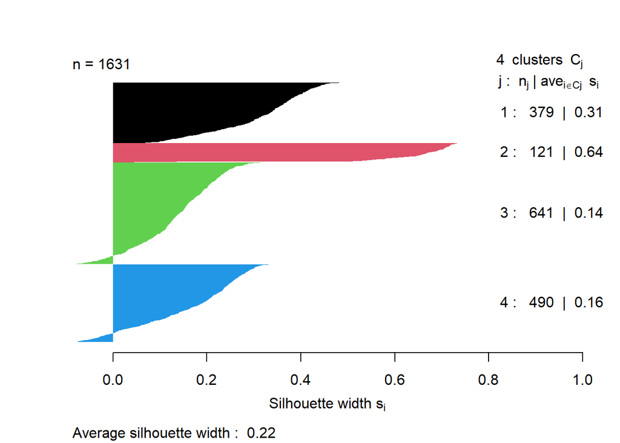

```r
d <- dist(X, method="euclidean")
sil = silhouette(groups.4,d)
plot(sil, col=1:4, main="", border=NA)
```

### K-means how many clusters should be chosen?

So previously we made a hypothesis on the number k let’s try to choose the best possible one, there is no optimal way to take that decision since we’re in the domain of unsupervised learning.

Let’s start by taking a look at the silhouette for different k. This method clearly prefers the value k = 3, the division in plane words would possibly be something like offensive player, defensive player and goalkeeper.

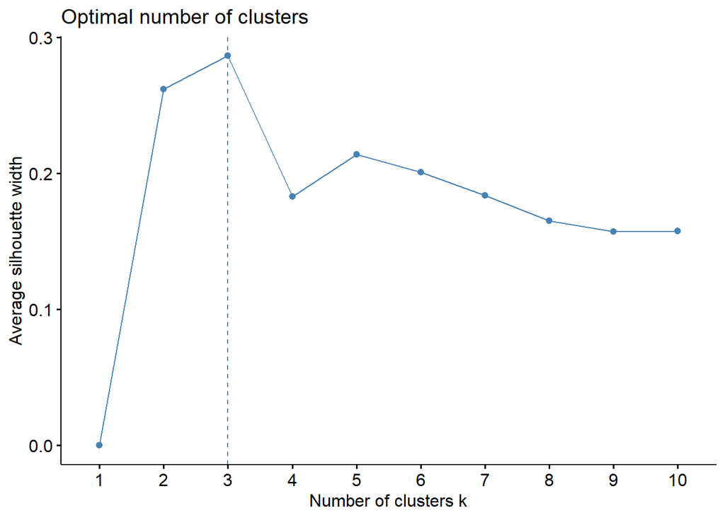

```r
fviz_nbclust(X, kmeans, method = 'silhouette')
```

With the within sum of square method we see that the elbow appears quite explicitly at number 4 which is the value of k we started with.

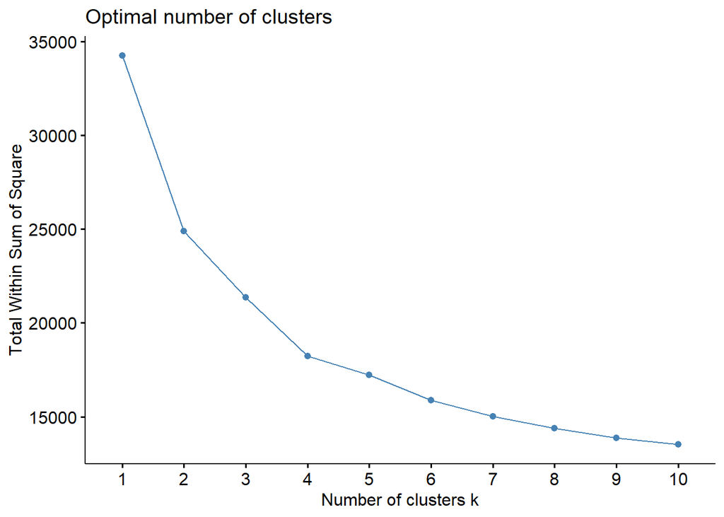

```r
fviz_nbclust(X, kmeans, method = 'wss')
```

With the gap statistic method, we see that the best number for k should be 3.

[output not shown]

[output cut: 46 more lines]

[output not shown]

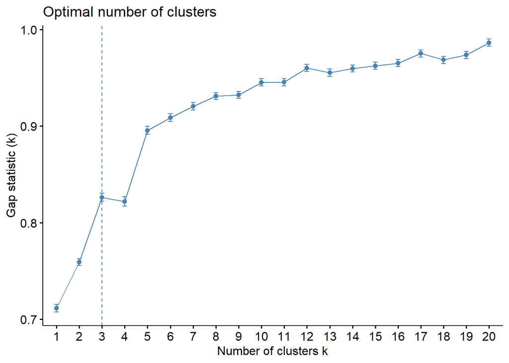

```r
fviz_nbclust(X, kmeans, method = 'gap_stat', k.max = 20)
```

Since the gap statistics and the silhouette method agree with each other plus we have already found a possible explication for that division we’re going to use k-means with k=3. The division we talked about is the one we see in the cluster plot. The offensively inclined players, the defensively inclined players and the goalkeepers.

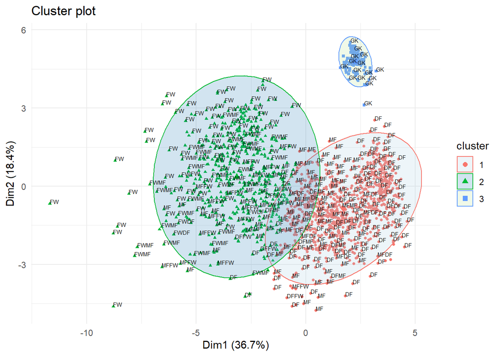

```r
fit.3 = kmeans(X, centers=3, nstart=100)
groups.3 = fit.3$cluster
centers3=fit.3$centers

fviz_cluster(fit.3, data = X, geom = c("point"),ellipse.type = 'norm', pointsize=1)+theme_minimal()+geom_text(label=players$position,hjust=0, vjust=0,size=2,check_overlap = T)+scale_fill_brewer(palette="Paired")
```

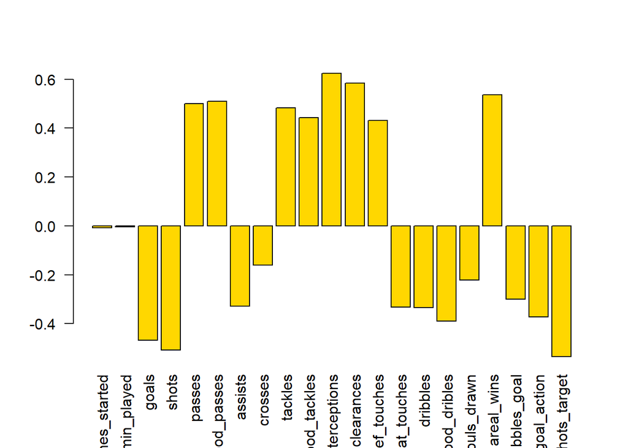

```r
# Center 1 :
bar1=barplot(centers3[1,], las=2, col="gold")
```

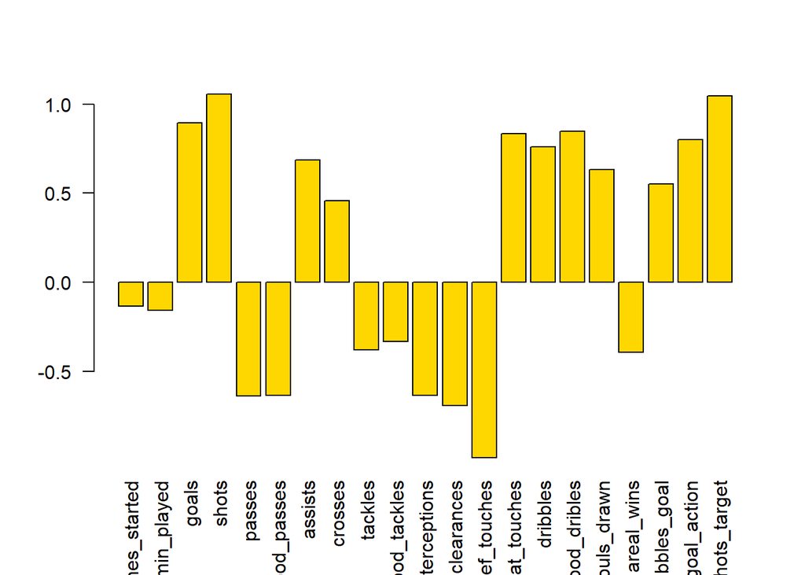

```r
# Center 2 :
bar1=barplot(centers3[2,], las=2, col="gold")
```

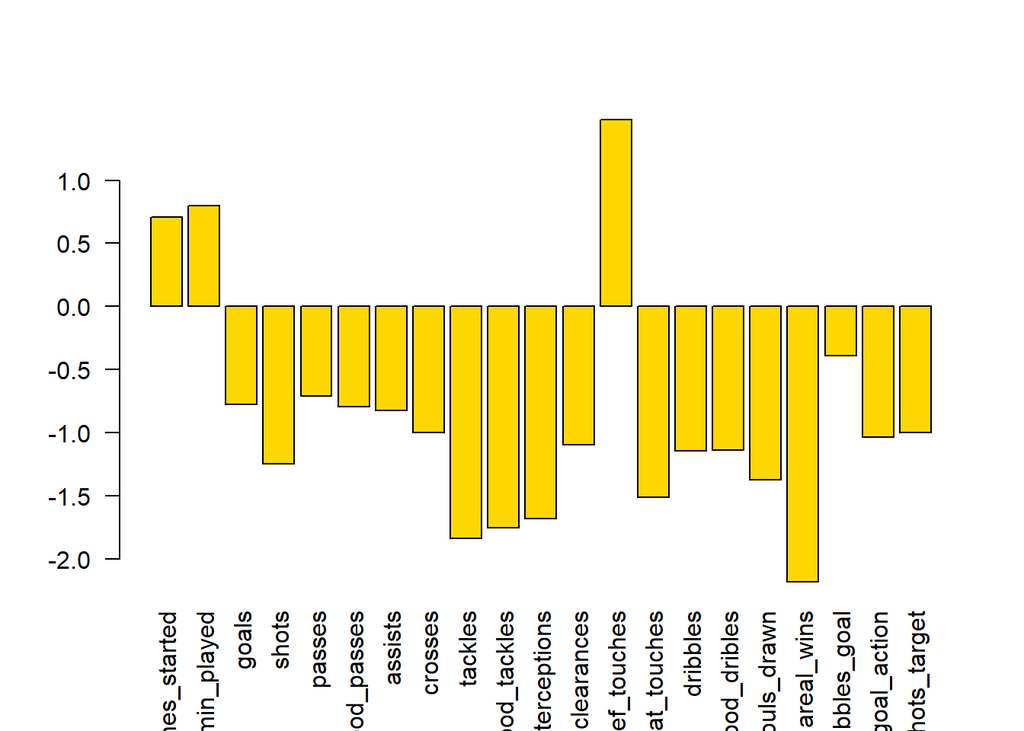

```r
# Center 3 :
bar1=barplot(centers3[3,], las=2, col="gold")
```

For our purpose of classifying player’s position, it might actually be better to keep 4 clusters because the 4th is quite efficient in classifying a middle fielder, by using 3 clusters we lose that information or rather we make it difficult to classify a player as MF.

### K-means with the multivariate standardization

We’re now going to use k-means with the mahalanobis distance instead of the euclidean distance. We’re going to keep working with 4 clusters.

```r
S_x <- cov(players.df)
iS <- solve(S_x)
e <- eigen(iS)
V <- e$vectors
B <- V %*% diag(sqrt(e$values)) %*% t(V)
Xtil <- scale( players.df,scale = FALSE)
playerS <- Xtil %*% B

fit.mahalanobis = kmeans(playerS, centers=4, nstart=100)
```

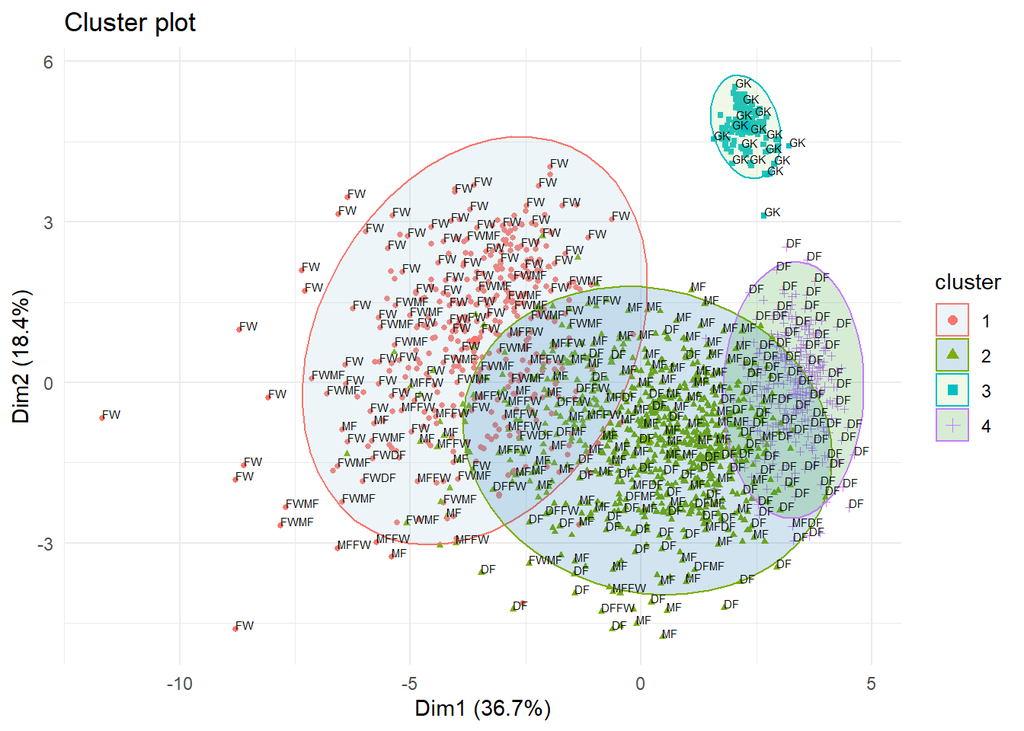

```r
groups = fit.mahalanobis$cluster
centers=fit.mahalanobis$centers
colnames(centers)=colnames(X)

fviz_cluster(fit.mahalanobis, data = X, geom = c("point"),ellipse.type = 'norm', pointsize=1)+theme_minimal()+geom_text(label=players$position,hjust=0, vjust=0,size=2,check_overlap = T)+scale_fill_brewer(palette="Paired")
```

The clusters with the 2 methods seem very similar, and we can say it is the case by looking at the similarity. 0.69 is close to 1 we can say that with both methods we have a similarity of 69%.

```r
adjustedRandIndex(fit.4$cluster, fit.mahalanobis$cluster)
```

```
## [1] 0.6907837
```

## Kernel K-means

```r
fit.ker <- kkmeans(as.matrix(X), centers=4, kernel="rbfdot")
```

```
## Using automatic sigma estimation (sigest) for RBF or laplace kernel
```

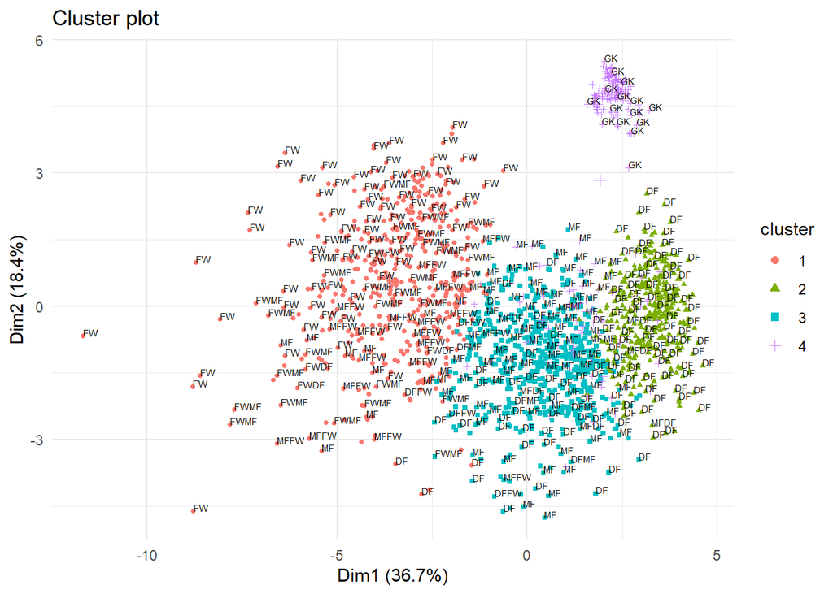

```r
#centers(fit.ker)
#size(fit.ker)
#withinss(fit.ker)

object.ker = list(data = X, cluster = fit.ker@.Data)
fviz_cluster(object.ker, geom = c("point"), ellipse=F,pointsize=1)+
  theme_minimal()+geom_text(label=players$position,hjust=0, vjust=0,size=2,check_overlap = T)+scale_fill_brewer(palette="Paired")
```

```r
adjustedRandIndex(fit.4$cluster, fit.ker)
```

```
## [1] 0.8635305
```

## PAM

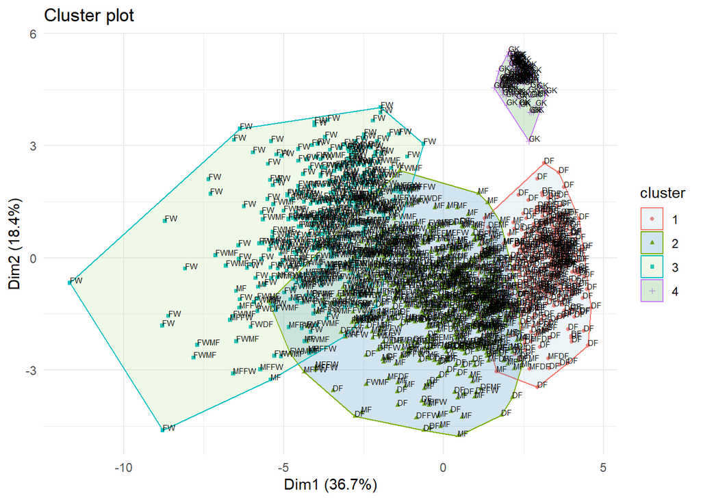

```r
fit.pam <- eclust(X, "pam", stand=TRUE, k=4, graph=F)

fviz_cluster(fit.pam, data = X, geom = c("point"), pointsize=1)+
  theme_minimal()+geom_text(label=players$position,hjust=0, vjust=0,size=2,check_overlap = F)+scale_fill_brewer(palette="Paired")
```

```r
adjustedRandIndex(fit.4$cluster, fit.pam$clustering)
```

```
## [1] 0.7599548
```

```r
adjustedRandIndex(fit.ker, fit.pam$clustering)
```

```
## [1] 0.6696231
```

## Hierarchical clustering

Now let’s take a look at Hierarchical clustering. note that the size of the data makes the plots very long on my pc even if I cut the data in half, so we’re only going to focus on the heatmap. We can take from that plot that there are 3 main separations in the variables, the offensive one going from shots to assists grouped together, the defensive one going from def_touches to areal_wins grouped together and between them is the play time variables. These chunks give a clear indication of the position a player.

[figure not shown]

```r
# Very long to compute on my machine
d = dist(X, method = "euclidean")
hc <- hclust(d, method = "ward.D2")


hc$labels <- players$names
#Loading time way too long...
fviz_dend(x = hc,
          k = 4,
          color_labels_by_k = TRUE,
          cex = 0.8,
          type = 'phylogenic',
          repel = TRUE) + theme(axis.text.x=element_blank(),axis.text.y=element_blank())+geom_text(label=players$name,hjust=0, vjust=0,size=2,check_overlap = F)
```

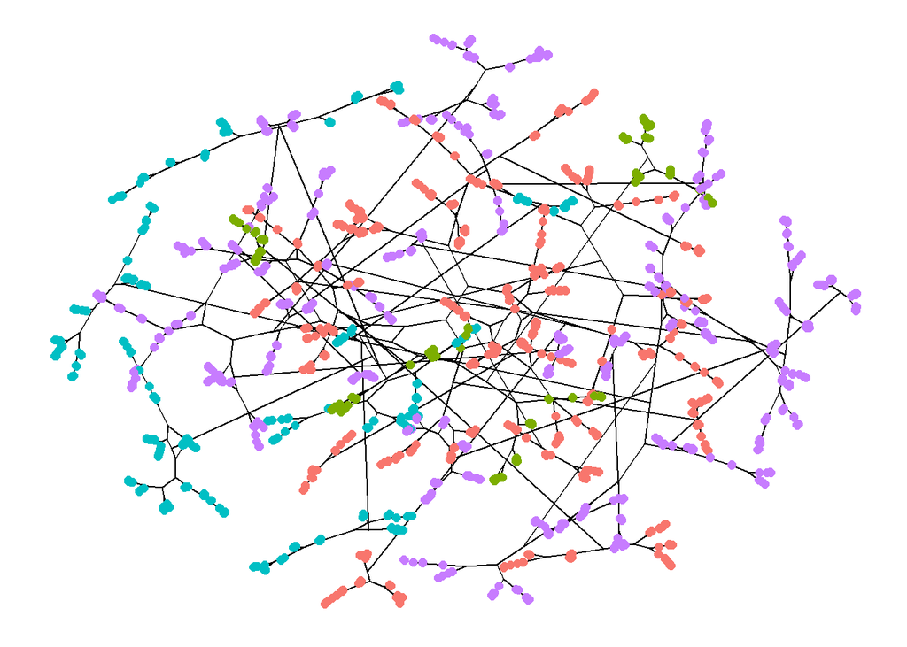

```r
fviz_dend(x = hc,
          k = 4,
          color_labels_by_k = TRUE,
          cex = 0.8,
          type = 'phylogenic',
          repel = TRUE)+ theme(axis.text.x=element_blank(),axis.text.y=element_blank())
```

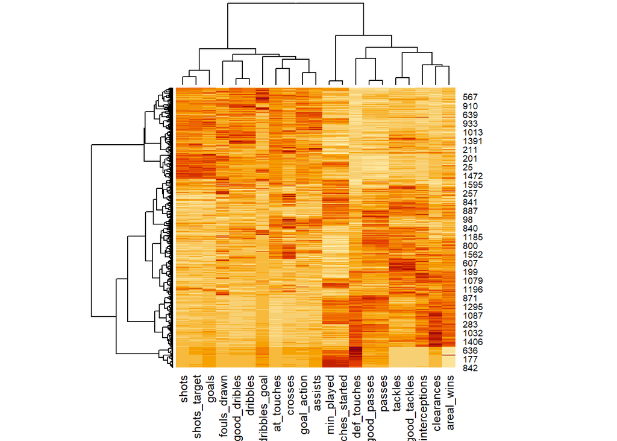

```r
heatmap(X,
        distfun = function(x){dist(x, method = "euclidean")},
        hclustfun = function(x){hclust(x, method = "ward.D2")},
        cexRow = 0.7)
```

## EM clustering

Finally, we can take a look at expectation maximization clustering, a more probabilistic method. Using BIT the optimal number of center is 6, and one we plot it seems like have overall two clusters for GK, two for MF, one for DF and one for FW, but by looking carefully we see that there are a lot of inconsistent values for our purpose of guessing the position, so this method would not be efficient for us.

```r
res.Mclust <- Mclust(X)
summary(res.Mclust)
```

```
## ----------------------------------------------------
## Gaussian finite mixture model fitted by EM algorithm
## ----------------------------------------------------
##
## Mclust VEV (ellipsoidal, equal shape) model with 6 components:
##
##  log-likelihood    n   df       BIC      ICL
##       -10759.86 1631 1417 -32001.19 -32043.8
##
## Clustering table:
##   1   2   3   4   5   6
## 744 176 443  72 151  45
```

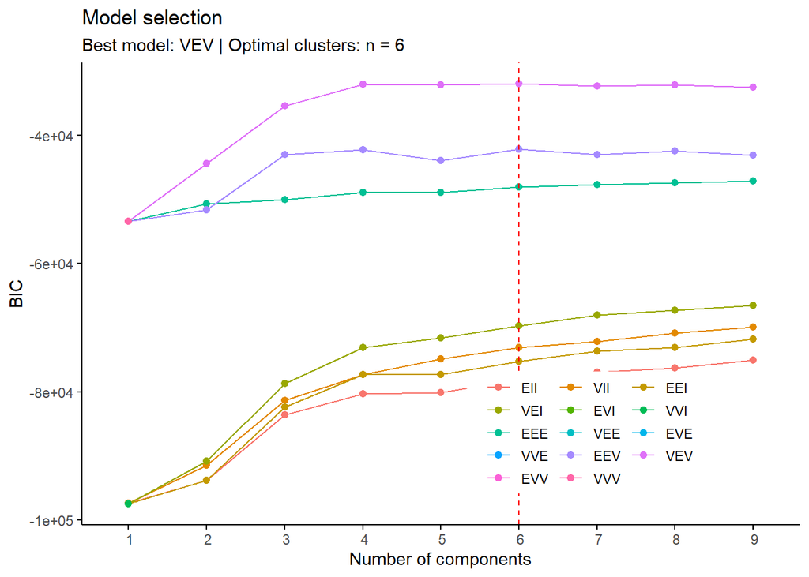

```r
fviz_mclust(object = res.Mclust, what = "BIC", pallete = "jco") +
  scale_x_discrete(limits = c(1:10))
```

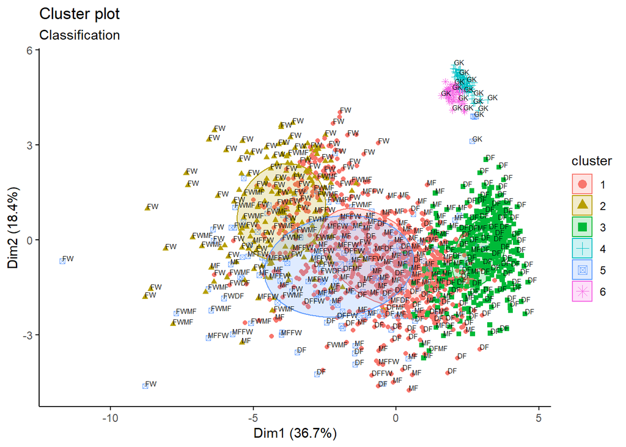

```r
fviz_mclust(object = res.Mclust, geom = "point",
            pallete = "jco")+geom_text(label=players$position,hjust=0, vjust=0,size=2,check_overlap = T)
```

# Conclusion

Trying to guess the real are best position of a player looking at it stats/game seems to work using most of the above tools, we can clearly see which for each position who excels the most but we still have to keep in mind that those stats have an enormous bias because you won’t have the ability to express certain skills in certain position, imagine if we have a very good striker but the coach decides to play him defender we wouldn’t be able to see where he plays best because his stats would mainly reflect the defensive responsibilities he has, this is the main problem with this data set analysis.

# Inspiration :

- All the notebooks seen in labs of statistical learning in UC3 Madrid